# MScFE Capstone Project

Aliaksandr Panko, Nadzeya Yakimchyk

August 4, 2019

# Introduction

Nowadays sustainable investment is a hot topic.

- Today more and more investors do not want to support weapons manufacturers and other companies, exploiting human weaknesses.
- New trend of making the world a better place forces portfolio managers to investigate Socially Responsible Investing (SRI) and take into account new requirements of investors.
- However, risk-adjusted returns, as a performance indicator, still play the most significant role.
- Having this in mind, researchers must answer how sustainable investing influence the performance.

# Literature review

Literature review showed that currently there is still no consensus whether responsible investing is a good bet for investors or not.

- “Optimists” camp showed that excluding worst (in terms of ESG scores) 10%-25% stocks leads to outperformance and does not harm diversification [25].
- “Neutral” camp, in their turn, are not so optimistic and just argue that there is no difference in alphas between “ESG winners” portfolio and “ESG losers” portfolio [9].
- From the opposite site, “Pessimists” camp claim that investors, who use ESG strategies, exposed to average loss of 40.6% annually in risk-adjusted returns. Moreover, they also argue that the underperformance is robust against different model specifications and test assets [7].
- However, there is one potential reason of such different results. There are several independent sustainability scores data providers, which could provide a bit different scores. Furthermore, many researchers in their papers used rather short time period, obviously, making all the findings less reliable.

# Research Question

There are researches that analyse funds performance, other make conclusions about performance of portfolios based on “sustainable” stocks. We are going to analyse our own portfolios, built from stocks with sustainability scores, not funds, whose portfolios can include only 50% of scored stocks.

Additionally, we would like to use longer period to include both expansions and recessions. Finally, we would like to dive deeper and investigate not only composite sustainability score (ESG), but also environmental (E), social (S), corporate governance (G) scores separately for both regions (USA and Europe) and check the robustness of results.

The aim of our research is to answer the main question: “Does investment into sustainable companies lower the overall portfolio performance or not?” Such formulation leads us to the next set of objectives:

1. Analyze consistency of the sustainability scores provided by different data suppliers for American and European markets.
2. Splitting all companies into clusters based on sustainability scores and forming corresponding portfolios, determine whether “Sustainable investing strategy” leads to underperformance in USA market.
3. Check the strategy performance also for European market and make a conclusion about the robustness of results.

# Methodology. Data Description. Datastream

From Datastream we downloaded the next data:

1. Returns of S&P 500 and Stoxx Europe 600 indices and weekly returns of their constituents. Weekly data from June 2003 to May 2018.
2. Filter for constituents of S&P 500 and Stoxx Europe 600 that shows for every stock whether it is a part of the index this week or not. Weekly data from June 2003 to May 2018.
3. Sustainability scores for constituents of S&P 500 and Stoxx Europe 600 indices: environmental (E), social (S), corporate governance (G), ESG and combined ESG (ESGCS) scores. Monthly data from December 2002 to December 2017.
4. Market capitalization for constituents of S&P 500 and Stoxx Europe 600 indices. Monthly data from June 2003 to May 2018.
5. Price-to-book ratio for constituents of S&P 500 and Stoxx Europe 600 indices. Monthly data from June 2003 to May 2018.
6. Firm information about constituents of S&P 500 and Stoxx Europe 600 indices, including firm name, industry and different stock identifiers.

# Methodology. Data Description. Sustainalytics

From Sustainalytics we downloaded the next data:

1. ESG score for constituents of MSCI USA and MSCI Europe indices. Weekly data from December 2009 to December 2017.
2. Firm information about constituents of MSCI USA and MSCI Europe indices, including firm name, industry and different stock identifiers.

# Methodolody for the Calculation of Sustainability Scores Provided by Datastream and Sustainalytics. Part 1

Datastream contains more than 400 ESG measures publicly disclosed by companies. Sustainability scores provided by Datastream are calculated based on 178 company-level key ESG measures. They are grouped into 10 categories, illustrated on Figure 1.

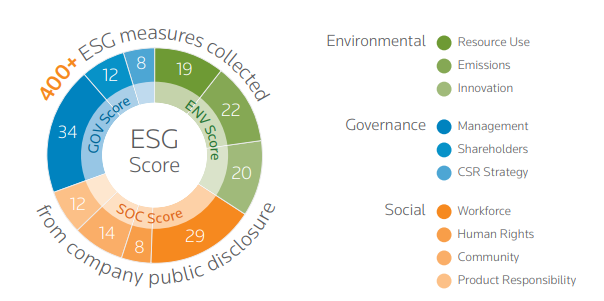

Datastream ESG Categories (Thomson Reuters ESG Scores 2019)

# Methodolody for the Calculation of Sustainability Scores Provided by Datastream and Sustainalytics. Part 2

A combination of the 10 categories, weighted proportionally to the number of measures within each category, delivers the three pillar scores and the final ESG score. Thus, E, S, G and ESG scores are calculated using the next formulas:

$$\begin{equation}
E = \frac{19}{61} Resource Use + \frac{22}{61} Emissions + \frac{20}{61} Innovation
\end{equation}$$
$$\begin{equation}
S = \frac{29}{63} Workforce + \frac{8}{63} Human Rights + \frac{14}{63} Community + \frac{12}{63} Product Responsibility
\end{equation}$$
$$\begin{equation}
G = \frac{34}{54} Management + \frac{12}{54} Shareholders + \frac{8}{54} CSR Strategy
\end{equation}$$
$$\begin{equation}
ESG = \frac{61}{178} E + \frac{63}{178} S + \frac{54}{178} G
\end{equation}$$

# Methodolody for the Calculation of Sustainability Scores Provided by Datastream and Sustainalytics. Part 3

Additionally, ESG Controversies Score is computed based on 23 controversy measures across all 10 categories.

Finally, ESG Combined Score (ESGCS) is calculated, according to the scheme described on Figure 2 [23].

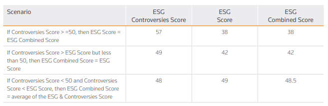

Final ESG Combined Score Assembly (Thomson Reuters ESG Scores 2019)

# Methodolody for the Calculation of Sustainability Scores Provided by Datastream and Sustainalytics. Part 4

ESG score, provided by Sustainalytics, measures how well companies solve the environmental, social and governance problems that can negatively affect their business and stakeholders.

The following indicators are assessed for the environmental, social and governance scores:

- Preparedness measures. How well company manages ESG risks through programs, policies and management systems?
- Disclosure indicators. Does company report according to best practice and notify about relevant ESG issues?
- Quantitative (e.g., amount of pollutant emission) and Qualitative (e.g., involvement in ESG controversies) performance measures [22].

# Capstone Project Methodology. Steps 1-3

The first step of our project is data download. We need to download from Datastream and Sustainalytics all required data

The second step is data preparation. We need to determine how many companies from index have E, S, G, ESG and ESGCS Datastream scores. The amount must be sufficient. Additionally, we introduce a new ESG Equal score that is equally-weighted average of E,S and G scores.

$$\begin{equation}
ESG_{Equal} = \frac{1}{3} E + \frac{1}{3} S + \frac{1}{3} G
\end{equation}$$

The third step answers the first core question: “How consistent are scores provided by different suppliers?” Consistency of the scores is analyzed by checking correlation between Sustainalytics ESG score and Datastream E, S, G, ESG, ESGCS and ESG Equal scores (6 sustainability scores in total).

# Capstone Project Methodology. Step 4

The fourth step deals with ESG-scores-based portfolios creation. The next substeps are required for each of 6 scores:

1. Split all companies into five clusters based on the sustainability score values in the way that portfolio 1 contains 20% of all companies with the lowest score, …, portfolio 5 contains 20% with the highest one.
2. Create five equally-weighted portfolios.
3. Reshuffle the portfolios in June of every year based on the sustainability score values from December of previous year. It is enough to reshuffle the portfolios once per year because Datastream sustainability scores are updated on annual basis.

Additionally, the all-best portfolio needs to be constructed. It contains stocks from top 20% of each E, S and G scores.

# Capstone Project Methodology. Step 5

The fifth step is performance analysis. Several indicators are important to reflect:

1. Average annual return
2. Annual standard deviation
3. Sharpe ratio
4. Cumulative return

These characteristics are compared with those of the benchmark index and all-best portfolio. This step will provide answer to the second core question: “Is it true that”bad" companies could give better performance and investing in “good” stocks could lead to underperformance?"

# Capstone Project Methodology. Step 6

In the sixth step we analyze size, value and momentum characteristics of the portfolios. Size score is represented by market capitalization, price-to-book ratio is used as a value score and momentum score is a six-month cumulative return. Then we need to apply normalization to these scores, that scales them in the range [0,1]. The next formula is used for normalization:

$$\begin{equation}
NormalizedScore = \frac{Score - ScoreMin}{ScoreMax - ScoreMin}
\end{equation}$$

Our claim is that ESG scores are positively correlated with company market capitalization (size effect).

# Capstone Project Methodology. Step 7

In the seventh step we analyze sensitivity to the market movements, calculating Market Beta, Bull and Bear Market Betas. Bull/Bear Market Beta measures sensitivity of a return of the stock to positive/negative return of the benchmark.

Additionally, we conduct the analysis above for double-sorted portfolios. Thus, we can capture the size effect. Firstly, we divide all stocks into two equal halves, based on the size score. Secondly, we divide each half into five parts based on the sustainability score. After that, we correspondingly merge stocks from both halves, forming five double-sorted portfolios in the result.

Finally, we examine robustness of our analysis, switching from S&P500 universe to Stoxx Europe 600 universe. The third core question of our research is supposed to be answered in this section. Having all the performance indicators and other results for USA market, we will check if the picture is the same for Europe.

# Capstone Project Methodology. Implementation

Regarding implementation, we use R language, which provides a powerful set of functions for data analysis and incredible visualization packages. Moreover, the final document is done using R knitr library, which helps to easily incorporate R results in .pdf document.

# Results. S&P 500 Universe. Number of Companies

The Figure 3 shows the number of companies in the S&P 500 index with existing sustainability scores. For all scores and all time points this value lays in the range [377;505] that is sufficient for the analysis. For every time point the number of companies with E, S and G scores is the same. The number of companies with ESG and ESGCS scores differs for 52 weeks.

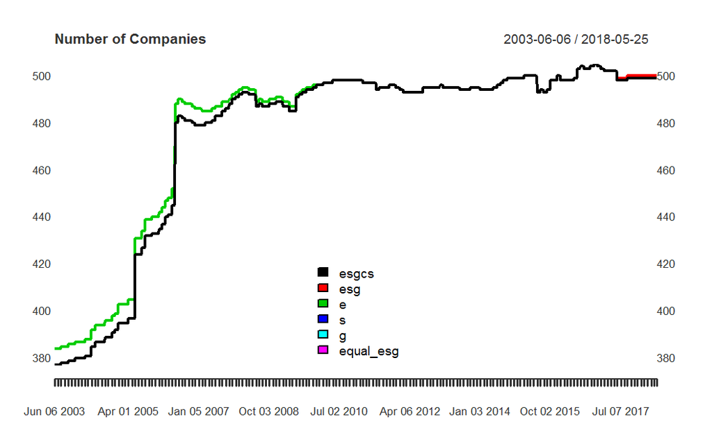

Figure 3: Number of Companies with Datastream Sustainability Scores

# Results. S&P 500 Universe. Correlation

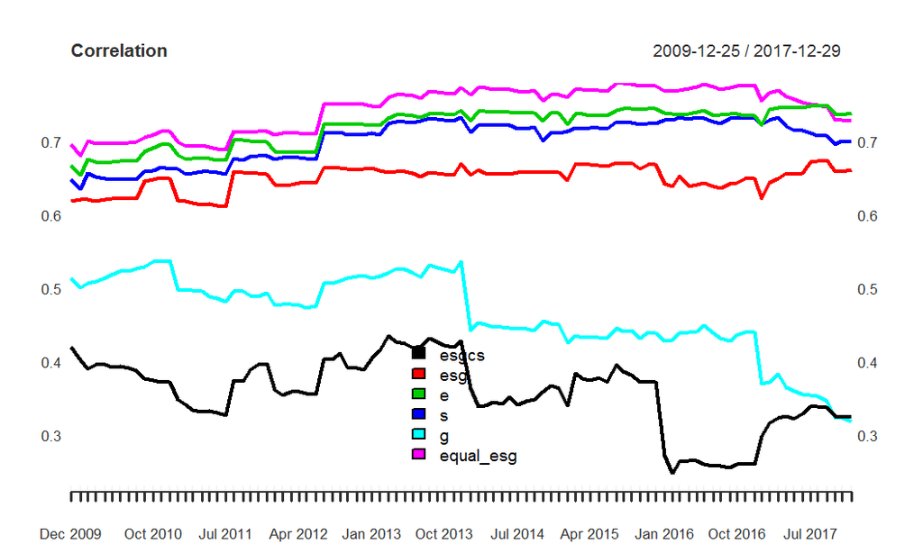

Figure 4: Correlation between Sustainalytics ESG Score and Datastream Sustainability Scores

# Results. S&P 500 Universe. Portfolios without Size Sorting. ESGCS

Figures 5 - 10 represent the cumulative returns for portfolios based on all six scores: ESGCS, E, S, G, ESG and Equal ESG. All 30 portfolios outperform the benchmark - S&P 500 index. For all scores, except of the S score, Portfolio 5, consisting of “good” companies in terms of sustainability, is one of the best performing portfolios.

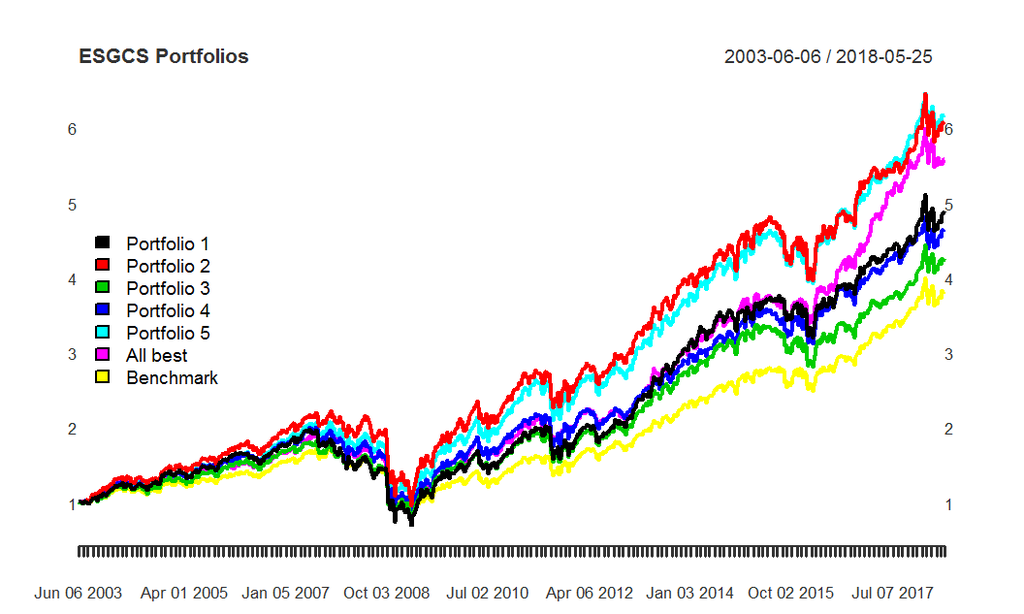

Figure 5: Cumulative Returns of ESGCS Portfolios

# Results. S&P 500 Universe. Portfolios without Size Sorting. E

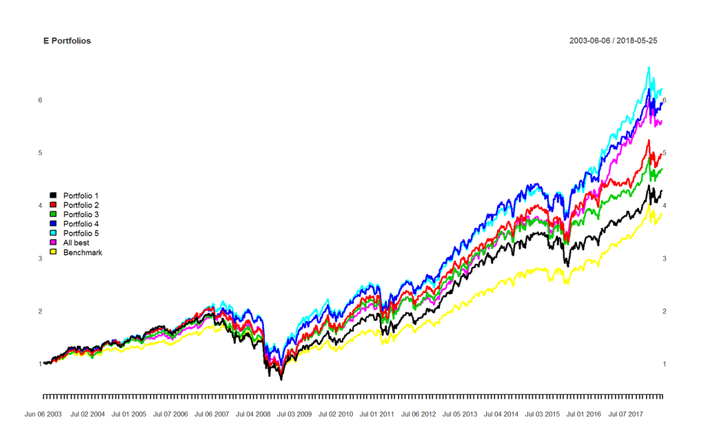

Figure 6: Cumulative Returns of E Portfolios

# Results. S&P 500 Universe. Portfolios without Size Sorting. S

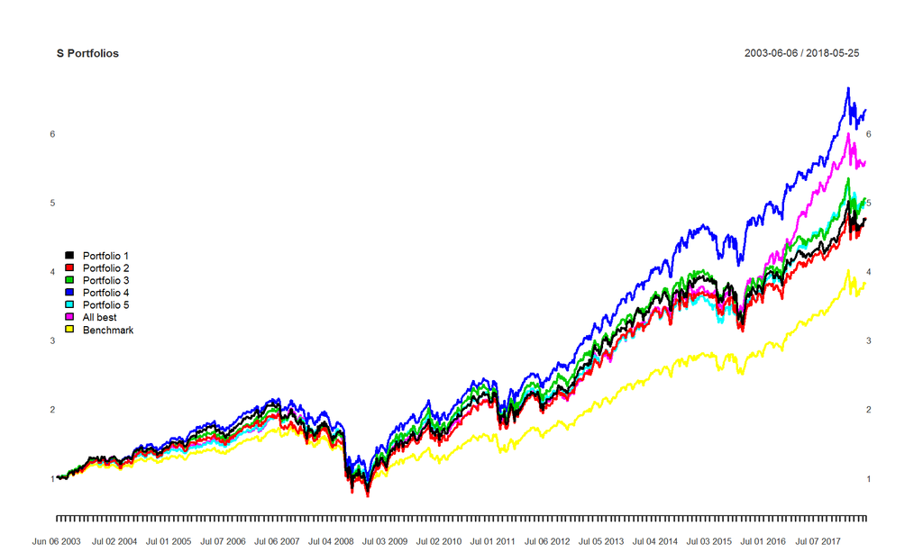

Figure 7: Cumulative Returns of S Portfolios

# Results. S&P 500 Universe. Portfolios without Size Sorting. G

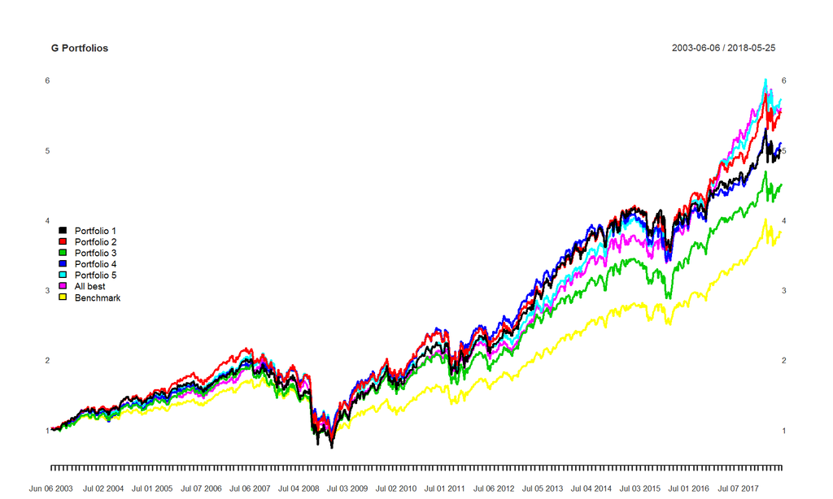

Figure 8: Cumulative Returns of G Portfolios

# Results. S&P 500 Universe. Portfolios without Size Sorting. ESG

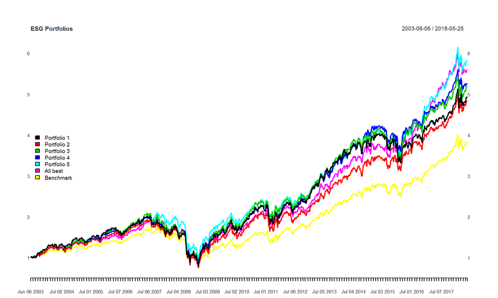

Figure 9: Cumulative Returns of ESG Portfolios

# Results. S&P 500 Universe. Portfolios without Size Sorting. Equal ESG

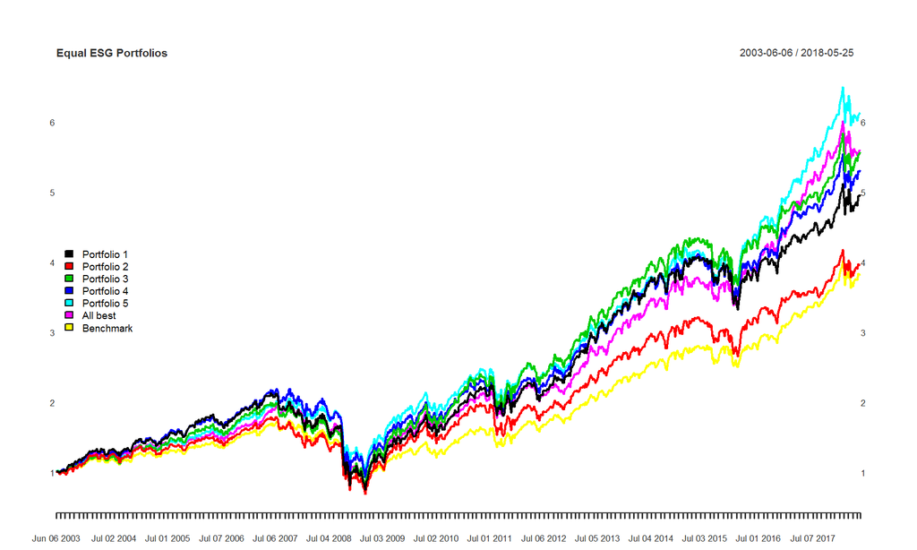

Figure 10: Cumulative Returns of Equal ESG Portfolios

# Results. S&P 500 Universe. Portfolios without Size Sorting. Average Annual Return

Tables 1-3 show average annual return, annual standard deviation and Sharpe ratio for constructed portfolios.

Table 1: Average Annual Return

|  | esgcs | esg | e | s | g | equal_esg |
| --- | --- | --- | --- | --- | --- | --- |
| **Portfolio 1** | 12.84 | 12.82 | 11.92 | 12.59 | 12.94 | 12.95 |
| **Portfolio 2** | 13.99 | 12.63 | 12.92 | 12.53 | 13.52 | 11.36 |
| **Portfolio 3** | 11.55 | 12.91 | 12.21 | 12.96 | 12 | 13.46 |
| **Portfolio 4** | 12 | 12.78 | 13.53 | 13.95 | 12.61 | 12.86 |
| **Portfolio 5** | 13.84 | 13.29 | 13.72 | 12.21 | 13.13 | 13.47 |

Based on average annual return, portfolio 5 outperforms portfolio 1 for all scores, except of the S score.

# Results. S&P 500 Universe. Portfolios without Size Sorting. Annual Standard Deviation

Table 2: Annual Standard Deviation

|  | esgcs | esg | e | s | g | equal_esg |
| --- | --- | --- | --- | --- | --- | --- |
| **Portfolio 1** | 21.12 | 20.86 | 21.12 | 20.87 | 21.12 | 21.31 |
| **Portfolio 2** | 19.68 | 20.64 | 21.17 | 20.5 | 20.49 | 20.91 |
| **Portfolio 3** | 19.32 | 19.7 | 19.48 | 20.81 | 19.7 | 20.06 |
| **Portfolio 4** | 18.64 | 18.39 | 18.1 | 18 | 18.69 | 18.54 |
| **Portfolio 5** | 18.38 | 17.59 | 17.73 | 17.15 | 17.25 | 16.64 |

The remarkable fact is that portfolio 5 has the lowest risk and portfolio 1 has the highest risk (except of E score), measured with standard deviation.

# Results. S&P 500 Universe. Portfolios without Size Sorting. Sharpe Ratio

Table 3: Sharpe Ratio

|  | esgcs | esg | e | s | g | equal_esg |
| --- | --- | --- | --- | --- | --- | --- |
| **Portfolio 1** | 0.56 | 0.57 | 0.52 | 0.56 | 0.57 | 0.56 |
| **Portfolio 2** | 0.66 | 0.56 | 0.56 | 0.56 | 0.61 | 0.5 |
| **Portfolio 3** | 0.55 | 0.6 | 0.58 | 0.57 | 0.56 | 0.62 |
| **Portfolio 4** | 0.59 | 0.64 | 0.69 | 0.72 | 0.62 | 0.64 |
| **Portfolio 5** | 0.7 | 0.7 | 0.72 | 0.65 | 0.7 | 0.75 |

Based on the Sharpe ratio, portfolio 5 is a winner for all scores, except of the S score.

# Results. S&P 500 Universe. Portfolios without Size Sorting. Benchmark and All-Best Portfolio Statistics

The table 4 contains statistics for the benchmark S&P 500 index and the all-best portfolio. The benchmark has the lowest both average annual return and annual standard deviation compared to all portfolios.

Table 4: Benchmark and All-Best Portfolio Statistics

|  | benchmark | all_best_portfolio |
| --- | --- | --- |
| **Average Annual Return** | 10.31 | 13.04 |
| **Annual Standard Deviation** | 16.34 | 17.78 |
| **Sharpe Ratio** | 0.57 | 0.68 |

# Results. S&P 500 Universe. Portfolios without Size Sorting. Average Sustainability Score

Tables 6-9 illustrate average sustainability, size, value and momentum scores for constructed portfolios.

Table 6: Average Sustainability Score

|  | esgcs | esg | e | s | g | equal_esg |
| --- | --- | --- | --- | --- | --- | --- |
| **Portfolio 1** | 26.97 | 33.77 | 14.32 | 18.17 | 54.01 | 33.24 |
| **Portfolio 2** | 35.8 | 47.54 | 30.74 | 38.86 | 72.97 | 49.06 |
| **Portfolio 3** | 42.47 | 56.64 | 53.28 | 57.15 | 81.29 | 63.28 |
| **Portfolio 4** | 51.16 | 65.75 | 74.17 | 76.06 | 87.11 | 76.47 |
| **Portfolio 5** | 66.83 | 78.12 | 91.56 | 91.28 | 93.26 | 89.37 |

We can see that portfolios differ significantly based on the average sustainability score.

# Results. S&P 500 Universe. Portfolios without Size Sorting. Average Size Score

Table 7: Average Size Score

|  | esgcs | esg | e | s | g | equal_esg |
| --- | --- | --- | --- | --- | --- | --- |
| **Portfolio 1** | 0.0491 | 0.0273 | 0.0312 | 0.0293 | 0.0403 | 0.029 |
| **Portfolio 2** | 0.0787 | 0.0306 | 0.0377 | 0.0382 | 0.0493 | 0.0321 |
| **Portfolio 3** | 0.0739 | 0.044 | 0.0403 | 0.0489 | 0.054 | 0.0491 |
| **Portfolio 4** | 0.0501 | 0.0684 | 0.0665 | 0.0734 | 0.0656 | 0.0719 |
| **Portfolio 5** | 0.0493 | 0.1271 | 0.1227 | 0.1099 | 0.0904 | 0.1164 |

Regarding the average size score, it increases monotonically from portfolio 1 to portfolio 5, except of the ESGCS score.

# Results. S&P 500 Universe. Portfolios without Size Sorting. Average Value Score

Table 8: Average Value Score

|  | esgcs | esg | e | s | g | equal_esg |
| --- | --- | --- | --- | --- | --- | --- |
| **Portfolio 1** | 0.5875 | 0.5863 | 0.5866 | 0.5872 | 0.5875 | 0.5866 |
| **Portfolio 2** | 0.5871 | 0.5891 | 0.5878 | 0.5884 | 0.589 | 0.5887 |
| **Portfolio 3** | 0.588 | 0.5882 | 0.589 | 0.5876 | 0.5873 | 0.588 |
| **Portfolio 4** | 0.5887 | 0.5877 | 0.5881 | 0.5887 | 0.5878 | 0.5886 |
| **Portfolio 5** | 0.5872 | 0.5871 | 0.5869 | 0.5867 | 0.5868 | 0.5867 |

However, the portfolios have almost the same average value scores.

# Results. S&P 500 Universe. Portfolios without Size Sorting. Average Momentum Score

Table 9: Average Momentum Score

|  | esgcs | esg | e | s | g | equal_esg |
| --- | --- | --- | --- | --- | --- | --- |
| **Portfolio 1** | 0.3843 | 0.3842 | 0.384 | 0.3845 | 0.3842 | 0.3845 |
| **Portfolio 2** | 0.3849 | 0.3846 | 0.3844 | 0.3844 | 0.3848 | 0.3833 |
| **Portfolio 3** | 0.3844 | 0.3844 | 0.3841 | 0.384 | 0.384 | 0.3848 |
| **Portfolio 4** | 0.3846 | 0.3852 | 0.3854 | 0.3862 | 0.3848 | 0.385 |
| **Portfolio 5** | 0.3855 | 0.3855 | 0.3859 | 0.3848 | 0.386 | 0.3861 |

The portfolios also have almost the same momentum.

# Results. S&P 500 Universe. Portfolios without Size Sorting. Market Betas

Table 10: Market Betas

|  | esgcs | esg | e | s | g | equal_esg |
| --- | --- | --- | --- | --- | --- | --- |
| **Portfolio 1** | 1.24 | 1.22 | 1.23 | 1.22 | 1.24 | 1.24 |
| **Portfolio 2** | 1.17 | 1.21 | 1.24 | 1.21 | 1.21 | 1.23 |
| **Portfolio 3** | 1.15 | 1.17 | 1.15 | 1.23 | 1.17 | 1.19 |
| **Portfolio 4** | 1.11 | 1.1 | 1.08 | 1.08 | 1.11 | 1.11 |
| **Portfolio 5** | 1.1 | 1.06 | 1.06 | 1.03 | 1.03 | 1 |

# Results. S&P 500 Universe. Portfolios without Size Sorting. Bull Market Betas

Table 11: Bull Market Betas

|  | esgcs | esg | e | s | g | equal_esg |
| --- | --- | --- | --- | --- | --- | --- |
| **Portfolio 1** | 1.35 | 1.34 | 1.35 | 1.31 | 1.36 | 1.35 |
| **Portfolio 2** | 1.23 | 1.32 | 1.35 | 1.33 | 1.31 | 1.36 |
| **Portfolio 3** | 1.24 | 1.23 | 1.23 | 1.31 | 1.25 | 1.26 |
| **Portfolio 4** | 1.16 | 1.13 | 1.09 | 1.1 | 1.17 | 1.12 |
| **Portfolio 5** | 1.13 | 1.09 | 1.1 | 1.08 | 1.05 | 1.02 |

# Results. S&P 500 Universe. Portfolios without Size Sorting. Bear Market Betas

Table 12: Bear Market Betas

|  | esgcs | esg | e | s | g | equal_esg |
| --- | --- | --- | --- | --- | --- | --- |
| **Portfolio 1** | 1.23 | 1.18 | 1.2 | 1.22 | 1.22 | 1.24 |
| **Portfolio 2** | 1.13 | 1.21 | 1.25 | 1.19 | 1.21 | 1.2 |
| **Portfolio 3** | 1.14 | 1.13 | 1.14 | 1.2 | 1.12 | 1.16 |
| **Portfolio 4** | 1.08 | 1.09 | 1.06 | 1.05 | 1.1 | 1.11 |
| **Portfolio 5** | 1.09 | 1.06 | 1.02 | 1.02 | 1.02 | 0.97 |

# Results. S&P 500 Universe. Double-Sorted Portfolios. ESGCS

Figures 11 - 16 represent the cumulative returns for portfolios based on all six scores after size sorting. All 30 portfolios outperform the benchmark - S&P 500 index. For all scores the all-best portfolio shows the best performance.

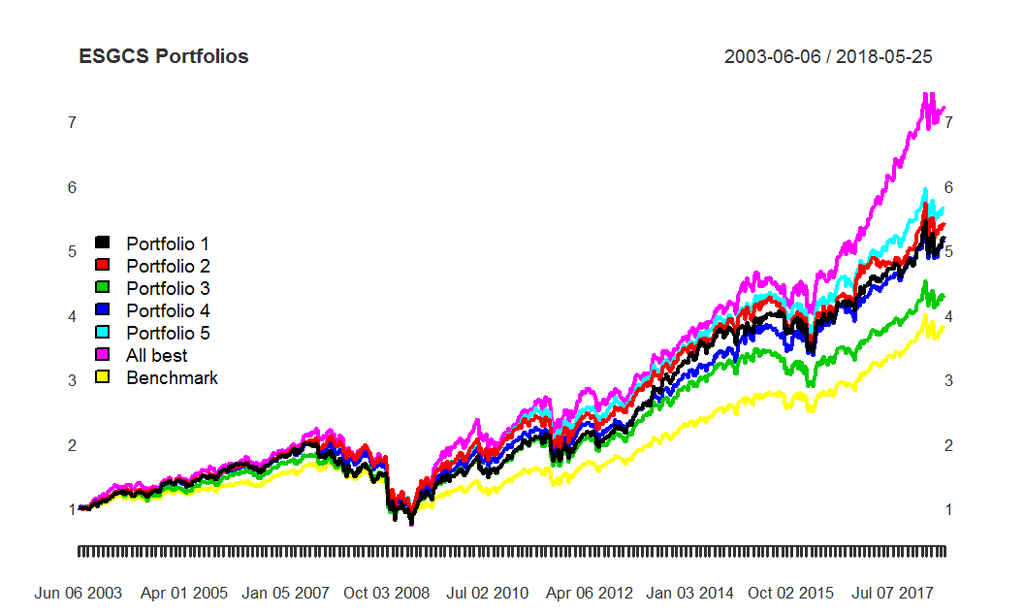

Figure 11: Cumulative Returns of ESGCS Portfolios

# Results. S&P 500 Universe. Double-Sorted Portfolios. E

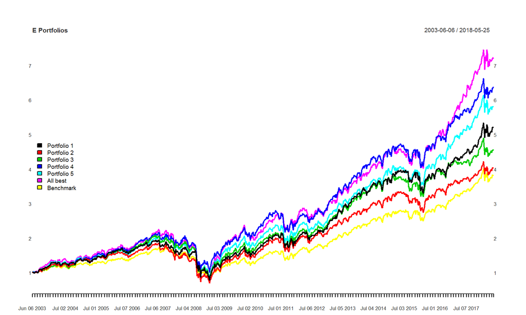

Figure 12: Cumulative Returns of E Portfolios

# Results. S&P 500 Universe. Double-Sorted Portfolios. S

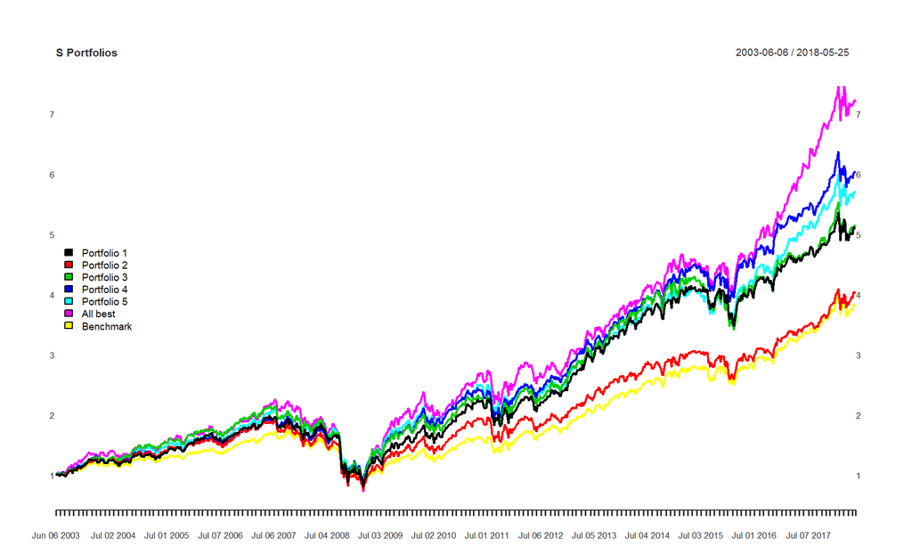

Figure 13: Cumulative Returns of S Portfolios

# Results. S&P 500 Universe. Double-Sorted Portfolios. G

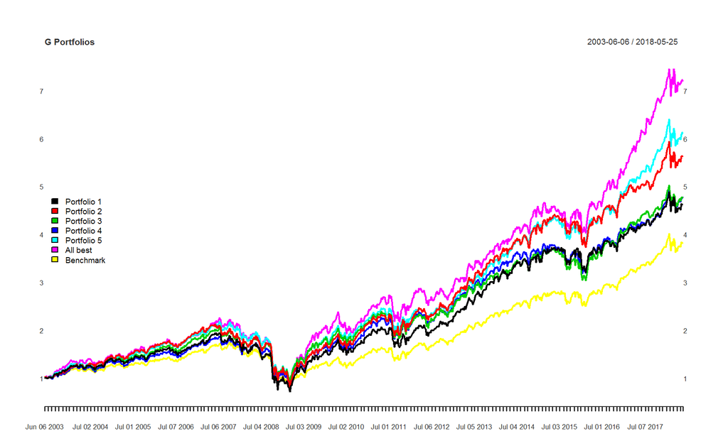

Figure 14: Cumulative Returns of G Portfolios

# Results. S&P 500 Universe. Double-Sorted Portfolios. ESG

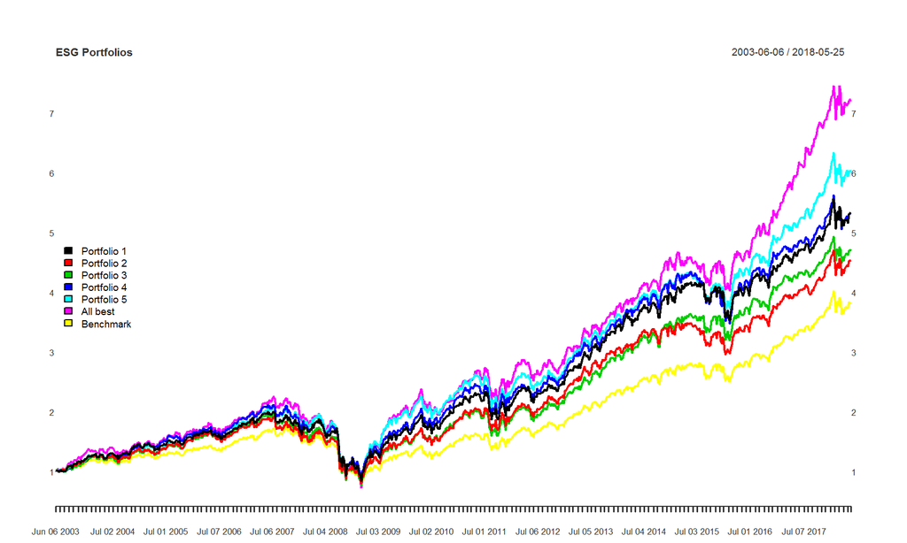

Figure 15: Cumulative Returns of ESG Portfolios

# Results. S&P 500 Universe. Double-Sorted Portfolios. Equal ESG

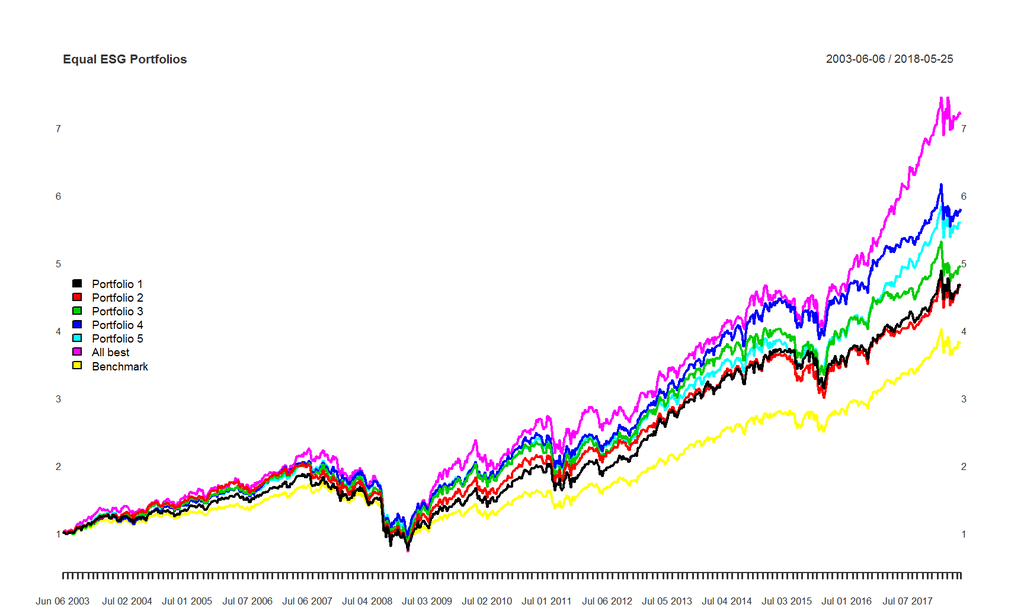

Figure 16: Cumulative Returns of Equal ESG Portfolios

# Results. S&P 500 Universe. Double-Sorted Portfolios. Average Annual Return

Tables 13-15 show average annual return, annual standard deviation and Sharpe ratio for double-sorted portfolios.

Table 13: Average Annual Return

|  | esgcs | esg | e | s | g | equal_esg |
| --- | --- | --- | --- | --- | --- | --- |
| **Portfolio 1** | 13.12 | 13.18 | 13.1 | 12.94 | 12.39 | 12.31 |
| **Portfolio 2** | 13.33 | 11.88 | 11.33 | 11.22 | 13.51 | 12.33 |
| **Portfolio 3** | 11.56 | 12.31 | 12.09 | 13 | 12.32 | 12.75 |
| **Portfolio 4** | 12.74 | 12.94 | 14.06 | 13.83 | 12.18 | 13.41 |
| **Portfolio 5** | 13.26 | 13.84 | 13.53 | 13.27 | 13.8 | 13.13 |

Based on average annual return, portfolio 5 outperforms portfolio 1 for all scores.

# Results. S&P 500 Universe. Double-Sorted Portfolios. Annual Standard Deviation

Table 14: Annual Standard Deviation

|  | esgcs | esg | e | s | g | equal_esg |
| --- | --- | --- | --- | --- | --- | --- |
| **Portfolio 1** | 20.43 | 20.04 | 20.38 | 20.36 | 20.88 | 20.07 |
| **Portfolio 2** | 20.2 | 18.95 | 20 | 19.44 | 19.9 | 20.46 |
| **Portfolio 3** | 19.01 | 19.76 | 19.76 | 20.25 | 19.42 | 20.31 |
| **Portfolio 4** | 18.93 | 19.02 | 18.46 | 19.15 | 18.6 | 18.36 |
| **Portfolio 5** | 18.43 | 19.14 | 18.98 | 18.18 | 18.46 | 18.17 |

The interesting fact is that portfolio 5 has the lowest risk (except of E and ESG scores) and portfolio 1 has the highest risk (except of Equal ESG score), measured with standard deviation.

# Results. S&P 500 Universe. Double-Sorted Portfolios. Sharpe Ratio

Table 15: Sharpe Ratio

|  | esgcs | esg | e | s | g | equal_esg |
| --- | --- | --- | --- | --- | --- | --- |
| **Portfolio 1** | 0.59 | 0.61 | 0.59 | 0.59 | 0.55 | 0.56 |
| **Portfolio 2** | 0.61 | 0.57 | 0.52 | 0.53 | 0.63 | 0.55 |
| **Portfolio 3** | 0.56 | 0.57 | 0.56 | 0.59 | 0.58 | 0.58 |
| **Portfolio 4** | 0.62 | 0.63 | 0.71 | 0.67 | 0.6 | 0.68 |
| **Portfolio 5** | 0.67 | 0.67 | 0.66 | 0.67 | 0.69 | 0.67 |

# Results. S&P 500 Universe. Double-Sorted Portfolios. Benchmark and All-Best Portfolio Statistics

The table 16 contains statistics for the benchmark S&P 500 index and the double-sorted all-best portfolio.

Table 16: Benchmark and All-Best Portfolio Statistics

|  | benchmark | all_best_portfolio |
| --- | --- | --- |
| **Average Annual Return** | 10.31 | 15.36 |
| **Annual Standard Deviation** | 16.34 | 21.08 |
| **Sharpe Ratio** | 0.57 | 0.68 |

The all-best portfolio has the highest both average annual return and annual standard deviation.

# Results. S&P 500 Universe. Double-Sorted Portfolios. Average Sustainability Score

Tables 17-20 illustrate average sustainability, size, value and momentum scores for double-sorted portfolios.

Table 17: Average Sustainability Score

|  | esgcs | esg | e | s | g | equal_esg |
| --- | --- | --- | --- | --- | --- | --- |
| **Portfolio 1** | 27.07 | 35.22 | 15.63 | 20.46 | 54.26 | 34.56 |
| **Portfolio 2** | 35.71 | 48.68 | 33.3 | 41.28 | 73.01 | 50.77 |
| **Portfolio 3** | 42.5 | 57.03 | 54.19 | 58.55 | 81.13 | 63.67 |
| **Portfolio 4** | 50.95 | 64.79 | 71.96 | 72.95 | 86.95 | 75.15 |
| **Portfolio 5** | 66.01 | 75.4 | 87.73 | 87.1 | 92.74 | 86.34 |

We can see that portfolios differ significantly based on the average sustainability score.

# Results. S&P 500 Universe. Double-Sorted Portfolios. Average Size Score

Table 18: Average Size Score

|  | esgcs | esg | e | s | g | equal_esg |
| --- | --- | --- | --- | --- | --- | --- |
| **Portfolio 1** | 0.0563 | 0.0386 | 0.0404 | 0.0428 | 0.0475 | 0.0383 |
| **Portfolio 2** | 0.0734 | 0.0417 | 0.0427 | 0.0465 | 0.0552 | 0.0454 |
| **Portfolio 3** | 0.0717 | 0.0545 | 0.0494 | 0.0594 | 0.0564 | 0.0607 |
| **Portfolio 4** | 0.0549 | 0.0689 | 0.0701 | 0.0688 | 0.0628 | 0.0682 |
| **Portfolio 5** | 0.0453 | 0.0941 | 0.0957 | 0.0822 | 0.0771 | 0.086 |

Regarding the average size score, it increases monotonically from portfolio 1 to portfolio 5, except of the ESGCS score.

# Results. S&P 500 Universe. Double-Sorted Portfolios. Average Value Score

Table 19: Average Value Score

|  | esgcs | esg | e | s | g | equal_esg |
| --- | --- | --- | --- | --- | --- | --- |
| **Portfolio 1** | 0.5877 | 0.5871 | 0.5867 | 0.5874 | 0.5877 | 0.5874 |
| **Portfolio 2** | 0.5871 | 0.5883 | 0.5881 | 0.5878 | 0.589 | 0.5877 |
| **Portfolio 3** | 0.5877 | 0.5886 | 0.5887 | 0.5888 | 0.5875 | 0.5884 |
| **Portfolio 4** | 0.5886 | 0.5877 | 0.5881 | 0.5876 | 0.5877 | 0.5885 |
| **Portfolio 5** | 0.5876 | 0.587 | 0.587 | 0.5868 | 0.5866 | 0.5866 |

The average value and momentum scores are almost the same.

# Results. S&P 500 Universe. Double-Sorted Portfolios. Average Momentum Score

Table 20: Average Momentum Score

|  | esgcs | esg | e | s | g | equal_esg |
| --- | --- | --- | --- | --- | --- | --- |
| **Portfolio 1** | 0.385 | 0.3859 | 0.3863 | 0.3863 | 0.3845 | 0.3858 |
| **Portfolio 2** | 0.3843 | 0.3849 | 0.3838 | 0.3843 | 0.3851 | 0.3845 |
| **Portfolio 3** | 0.3843 | 0.3848 | 0.384 | 0.3839 | 0.3843 | 0.3837 |
| **Portfolio 4** | 0.3849 | 0.3844 | 0.3852 | 0.385 | 0.3842 | 0.3851 |
| **Portfolio 5** | 0.3852 | 0.3838 | 0.3844 | 0.3842 | 0.3856 | 0.3846 |

# Results. S&P 500 Universe. Double-Sorted Portfolios. Market Betas

Table 21: Market Betas

|  | esgcs | esg | e | s | g | equal_esg |
| --- | --- | --- | --- | --- | --- | --- |
| **Portfolio 1** | 1.21 | 1.18 | 1.2 | 1.2 | 1.23 | 1.19 |
| **Portfolio 2** | 1.19 | 1.13 | 1.18 | 1.15 | 1.18 | 1.21 |
| **Portfolio 3** | 1.13 | 1.17 | 1.17 | 1.2 | 1.15 | 1.2 |
| **Portfolio 4** | 1.13 | 1.13 | 1.1 | 1.13 | 1.11 | 1.09 |
| **Portfolio 5** | 1.1 | 1.13 | 1.12 | 1.08 | 1.1 | 1.08 |

# Results. S&P 500 Universe. Double-Sorted Portfolios. Bull Market Betas

Table 22: Bull Market Betas

|  | esgcs | esg | e | s | g | equal_esg |
| --- | --- | --- | --- | --- | --- | --- |
| **Portfolio 1** | 1.29 | 1.27 | 1.29 | 1.28 | 1.33 | 1.27 |
| **Portfolio 2** | 1.29 | 1.19 | 1.25 | 1.26 | 1.27 | 1.33 |
| **Portfolio 3** | 1.2 | 1.26 | 1.26 | 1.25 | 1.24 | 1.28 |
| **Portfolio 4** | 1.19 | 1.18 | 1.15 | 1.21 | 1.16 | 1.13 |
| **Portfolio 5** | 1.13 | 1.19 | 1.17 | 1.13 | 1.13 | 1.12 |

# Results. S&P 500 Universe. Double-Sorted Portfolios. Bear Market Betas

Table 23: Bear Market Betas

|  | esgcs | esg | e | s | g | equal_esg |
| --- | --- | --- | --- | --- | --- | --- |
| **Portfolio 1** | 1.19 | 1.16 | 1.17 | 1.2 | 1.21 | 1.18 |
| **Portfolio 2** | 1.16 | 1.09 | 1.18 | 1.13 | 1.18 | 1.18 |
| **Portfolio 3** | 1.13 | 1.16 | 1.16 | 1.19 | 1.12 | 1.19 |
| **Portfolio 4** | 1.1 | 1.11 | 1.07 | 1.09 | 1.08 | 1.06 |
| **Portfolio 5** | 1.08 | 1.13 | 1.08 | 1.06 | 1.09 | 1.06 |

# Results. Stoxx Europe 600 Universe. Number of Companies with Datastream Sustainability Scores

The Figure 17 shows the number of companies in the Stoxx Europe 600 index with existing sustainability scores. For all scores and all time points this value lays in the range [345;599] that is sufficient for the analysis. For every time point the number of companies with ESG and ESGCS scores is the same. The number of companies with E score matches that for S scores, while for G score this indicator differs from them for 4 weeks.

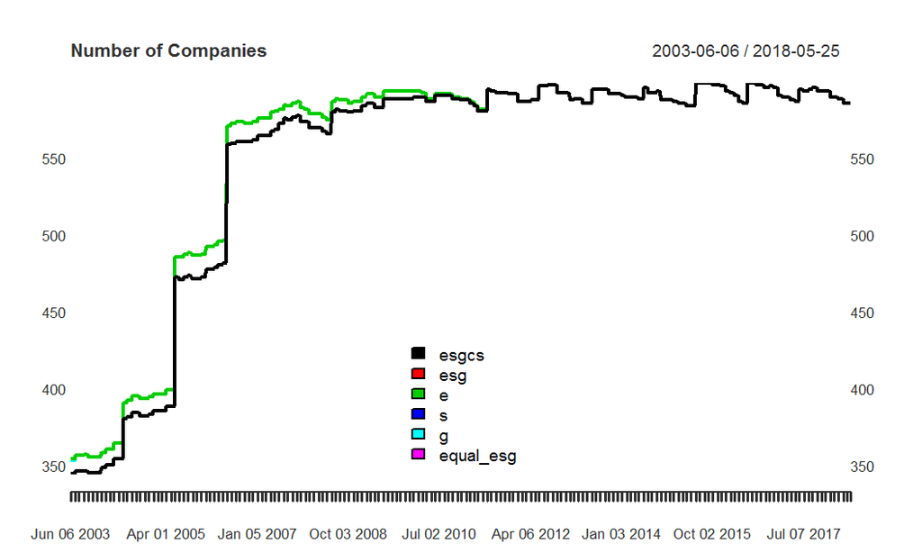

Figure 17: Number of Companies with Datastream Sustainability Scores

# Results. Stoxx Europe 600 Universe. Correlation

In the Figure 18 correlation between Sustainalytics ESG score and Datastream sustainability scores is illustrated. In all cases correlation is positive. The highest correlation of about 0.6 is observed for S score, while ESGCS and G scores have the lowest correlation with the Sustainalytics ESG score (smaller than 0.4)

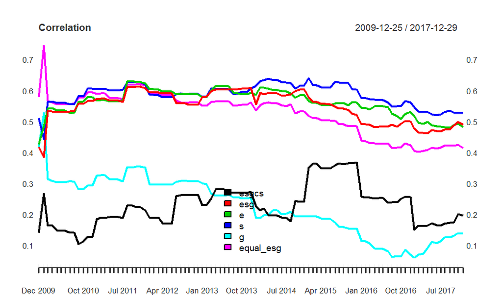

Figure 18: Correlation between Sustainalytics ESG Score and Datastream Sustainability Scores

# Results. Stoxx Europe 600 Universe. Portfolios without Size Sorting. ESGCS

Figures 19 - 24 represent the cumulative returns for portfolios based on all six scores: ESGCS, E, S, G, ESG and Equal ESG. All 30 portfolios outperform the benchmark - Stoxx Europe 600 index. For all scores, except of the ESGCS score, Portfolio 2 performs best. The worst performing for all scores is the all-best portfolio.

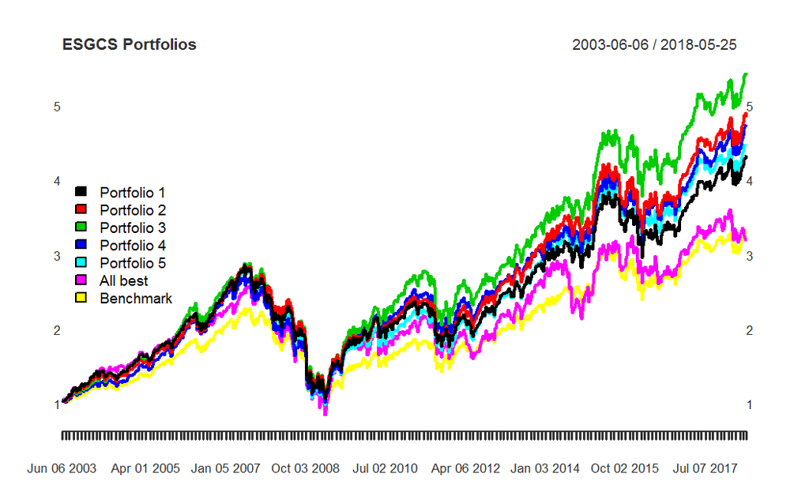

Figure 19: Cumulative Returns of ESGCS Portfolios

# Results. Stoxx Europe 600 Universe. Portfolios without Size Sorting. E

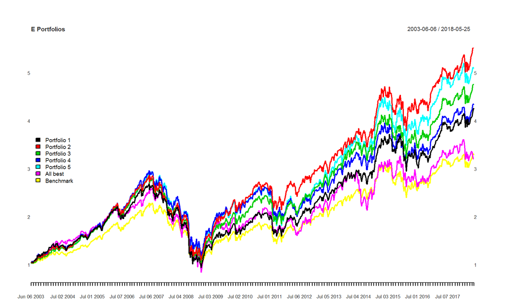

Figure 20: Cumulative Returns of E Portfolios

# Results. Stoxx Europe 600 Universe. Portfolios without Size Sorting. S

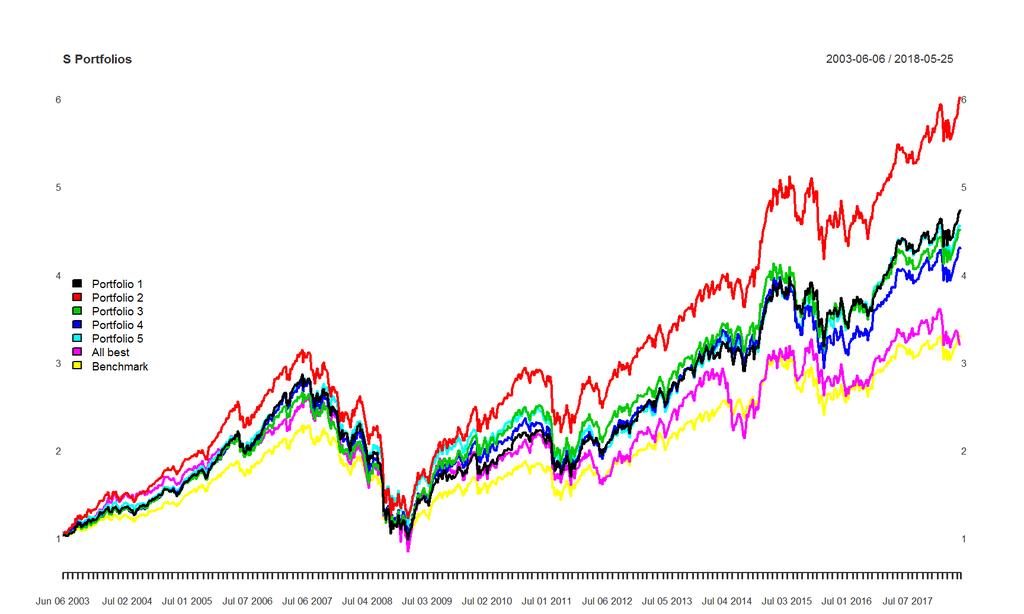

Figure 21: Cumulative Returns of S Portfolios

# Results. Stoxx Europe 600 Universe. Portfolios without Size Sorting. G

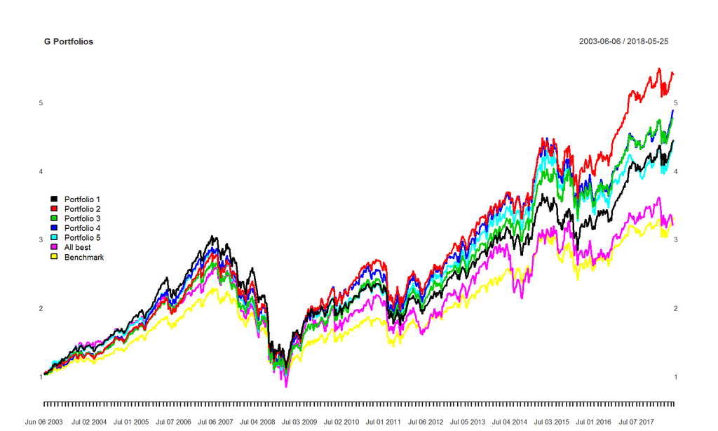

Figure 22: Cumulative Returns of G Portfolios

# Results. Stoxx Europe 600 Universe. Portfolios without Size Sorting. ESG

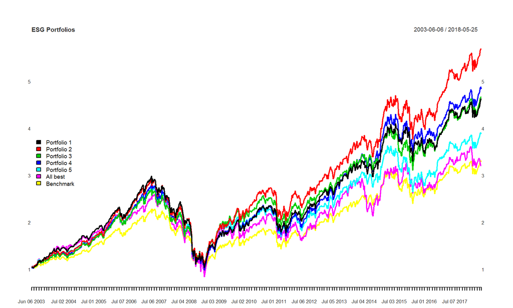

Figure 23: Cumulative Returns of ESG Portfolios

# Results. Stoxx Europe 600 Universe. Portfolios without Size Sorting. Equal ESG

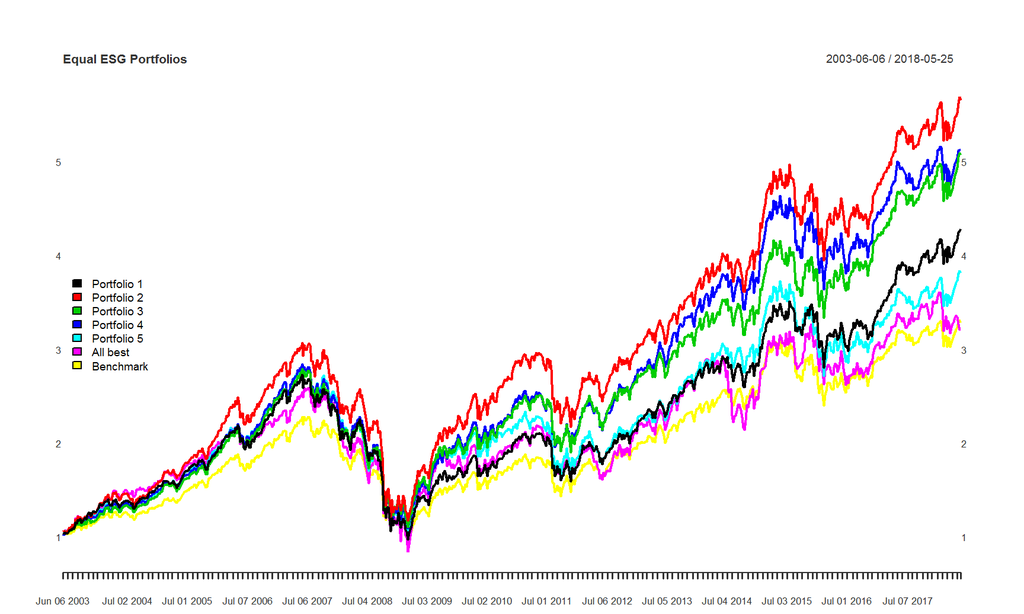

Figure 24: Cumulative Returns of Equal ESG Portfolios

# Results. Stoxx Europe 600 Universe. Portfolios without Size Sorting. Average Annual Return

Tables 24-26 show average annual return, annual standard deviation and Sharpe ratio for constructed portfolios.

Table 24: Average Annual Return

|  | esgcs | esg | e | s | g | equal_esg |
| --- | --- | --- | --- | --- | --- | --- |
| **Portfolio 1** | 11.57 | 11.95 | 11.46 | 12.16 | 11.61 | 11.42 |
| **Portfolio 2** | 12.44 | 13.45 | 13.18 | 13.83 | 13 | 13.41 |
| **Portfolio 3** | 13.08 | 12.11 | 12.17 | 12.03 | 12.2 | 12.64 |
| **Portfolio 4** | 12.29 | 12.45 | 11.65 | 11.62 | 12.7 | 12.82 |
| **Portfolio 5** | 11.89 | 11.08 | 13.03 | 11.96 | 12.02 | 11.03 |

Based on average annual return, no patterns are defined.

# Results. Stoxx Europe 600 Universe. Portfolios without Size Sorting.Annual Standard Deviation

Table 25: Annual Standard Deviation

|  | esgcs | esg | e | s | g | equal_esg |
| --- | --- | --- | --- | --- | --- | --- |
| **Portfolio 1** | 18.73 | 18.44 | 18.76 | 18.78 | 18.08 | 18.4 |
| **Portfolio 2** | 19.48 | 19.15 | 18.89 | 19.2 | 18.67 | 19.19 |
| **Portfolio 3** | 19 | 19.04 | 18.76 | 19.89 | 18.93 | 18.97 |
| **Portfolio 4** | 19.39 | 19.57 | 19.26 | 19.42 | 20.55 | 19.54 |
| **Portfolio 5** | 19.41 | 20.04 | 20.74 | 19.19 | 20.53 | 20.31 |

# Results. Stoxx Europe 600 Universe. Portfolios without Size Sorting.Sharpe Ratio

Table 26: Sharpe Ratio

|  | esgcs | esg | e | s | g | equal_esg |
| --- | --- | --- | --- | --- | --- | --- |
| **Portfolio 1** | 0.56 | 0.59 | 0.56 | 0.59 | 0.59 | 0.57 |
| **Portfolio 2** | 0.59 | 0.65 | 0.64 | 0.67 | 0.64 | 0.65 |
| **Portfolio 3** | 0.64 | 0.58 | 0.6 | 0.55 | 0.59 | 0.61 |
| **Portfolio 4** | 0.58 | 0.59 | 0.55 | 0.55 | 0.57 | 0.6 |
| **Portfolio 5** | 0.56 | 0.5 | 0.58 | 0.57 | 0.54 | 0.49 |

Portfolio 1 has greater or equal Sharpe ratio than portfolio 5, except of the E score.

# Results. Stoxx Europe 600 Universe. Portfolios without Size Sorting. Benchmark and All-Best Portfolio Statistics

The table 27 contains statistics for the benchmark Stoxx Europe 600 index and the all-best portfolio. The benchmark has the lowest both average annual return and annual standard deviation compared to all portfolios. Excluding from consideration the benchmark, the all-best portfolio has the worst characteristics.

Table 27: Benchmark and All-Best Portfolio Statistics

|  | benchmark | all_best_portfolio |
| --- | --- | --- |
| **Average Annual Return** | 9.56 | 10.61 |
| **Annual Standard Deviation** | 17.88 | 23.58 |
| **Sharpe Ratio** | 0.48 | 0.41 |

# Results. Stoxx Europe 600 Universe. Portfolios without Size Sorting. Average Sustainability Score

Tables 28-31 illustrate average sustainability, size, value and momentum scores for constructed portfolios.

Table 28: Average Sustainability Score

|  | esgcs | esg | e | s | g | equal_esg |
| --- | --- | --- | --- | --- | --- | --- |
| **Portfolio 1** | 31.57 | 36.93 | 24.52 | 27.24 | 18.32 | 30.35 |
| **Portfolio 2** | 41.8 | 51.95 | 57.16 | 61.16 | 42.79 | 57.03 |
| **Portfolio 3** | 50.25 | 61.06 | 79.51 | 79.67 | 61.62 | 71.35 |
| **Portfolio 4** | 60.86 | 69.19 | 89.97 | 89.88 | 75.35 | 80.8 |
| **Portfolio 5** | 73.39 | 79.57 | 94.37 | 95.68 | 88.17 | 88.97 |

We can see that portfolios differ significantly based on the average sustainability score.

# Results. Stoxx Europe 600 Universe. Portfolios without Size Sorting. Average Size Score

Table 29: Average Size Score

|  | esgcs | esg | e | s | g | equal_esg |
| --- | --- | --- | --- | --- | --- | --- |
| **Portfolio 1** | 0.0211 | 0.0118 | 0.0116 | 0.0118 | 0.0192 | 0.0143 |
| **Portfolio 2** | 0.0344 | 0.0153 | 0.0147 | 0.015 | 0.0265 | 0.0158 |
| **Portfolio 3** | 0.0222 | 0.021 | 0.0225 | 0.0249 | 0.0271 | 0.0257 |
| **Portfolio 4** | 0.0196 | 0.0298 | 0.0343 | 0.0347 | 0.0261 | 0.0309 |
| **Portfolio 5** | 0.0262 | 0.0453 | 0.0397 | 0.0362 | 0.0241 | 0.036 |

Regarding the average size score, it increases monotonically from portfolio 1 to portfolio 5, except of ESGCS and G score.

# Results. Stoxx Europe 600 Universe. Portfolios without Size Sorting. Average Value Score

Table 30: Average Value Score

|  | esgcs | esg | e | s | g | equal_esg |
| --- | --- | --- | --- | --- | --- | --- |
| **Portfolio 1** | 0.3772 | 0.3781 | 0.379 | 0.3785 | 0.3768 | 0.3788 |
| **Portfolio 2** | 0.377 | 0.3784 | 0.3775 | 0.3783 | 0.3772 | 0.3775 |
| **Portfolio 3** | 0.3782 | 0.3769 | 0.3773 | 0.376 | 0.3783 | 0.3767 |
| **Portfolio 4** | 0.3773 | 0.3766 | 0.3762 | 0.377 | 0.3768 | 0.3769 |
| **Portfolio 5** | 0.3768 | 0.3765 | 0.3764 | 0.3766 | 0.3772 | 0.3765 |

The value and momentum scores are almost the same on average.

# Results. Stoxx Europe 600 Universe. Portfolios without Size Sorting. Average Momentum Score

Table 31: Average Momentum Score

|  | esgcs | esg | e | s | g | equal_esg |
| --- | --- | --- | --- | --- | --- | --- |
| **Portfolio 1** | 0.4136 | 0.4139 | 0.4134 | 0.4142 | 0.4136 | 0.4135 |
| **Portfolio 2** | 0.4139 | 0.4151 | 0.4147 | 0.4153 | 0.4147 | 0.415 |
| **Portfolio 3** | 0.4147 | 0.4135 | 0.4144 | 0.4134 | 0.4143 | 0.4144 |
| **Portfolio 4** | 0.4139 | 0.4143 | 0.4136 | 0.4136 | 0.4143 | 0.4143 |
| **Portfolio 5** | 0.4138 | 0.4129 | 0.4141 | 0.4137 | 0.4132 | 0.4128 |

# Results. Stoxx Europe 600 Universe. Portfolios without Size Sorting. Market Betas

Table 32: Market Betas

|  | esgcs | esg | e | s | g | equal_esg |
| --- | --- | --- | --- | --- | --- | --- |
| **Portfolio 1** | 1.01 | 0.98 | 1 | 1 | 0.96 | 0.98 |
| **Portfolio 2** | 1.06 | 1.03 | 1.01 | 1.03 | 1.01 | 1.03 |
| **Portfolio 3** | 1.03 | 1.03 | 1.02 | 1.07 | 1.03 | 1.03 |
| **Portfolio 4** | 1.05 | 1.07 | 1.05 | 1.06 | 1.11 | 1.07 |
| **Portfolio 5** | 1.06 | 1.1 | 1.13 | 1.05 | 1.1 | 1.11 |

# Results. Stoxx Europe 600 Universe. Portfolios without Size Sorting. Bull Market Betas

Table 33: Bull Market Betas

|  | esgcs | esg | e | s | g | equal_esg |
| --- | --- | --- | --- | --- | --- | --- |
| **Portfolio 1** | 0.98 | 0.95 | 0.97 | 0.97 | 0.9 | 0.93 |
| **Portfolio 2** | 1.08 | 1.02 | 1.03 | 1.03 | 0.99 | 1.01 |
| **Portfolio 3** | 1.05 | 1.05 | 1.01 | 1.11 | 1.02 | 1.04 |
| **Portfolio 4** | 1.06 | 1.07 | 1.06 | 1.06 | 1.16 | 1.09 |
| **Portfolio 5** | 1.06 | 1.13 | 1.17 | 1.06 | 1.17 | 1.15 |

# Results. Stoxx Europe 600 Universe. Portfolios without Size Sorting. Bear Market Betas

Table 34: Bear Market Betas

|  | esgcs | esg | e | s | g | equal_esg |
| --- | --- | --- | --- | --- | --- | --- |
| **Portfolio 1** | 1 | 1.03 | 1.04 | 1.06 | 1 | 1.03 |
| **Portfolio 2** | 1.08 | 1.05 | 1.01 | 1.03 | 1.04 | 1.05 |
| **Portfolio 3** | 1.04 | 1.01 | 1.03 | 1.08 | 1.02 | 1.01 |
| **Portfolio 4** | 1.07 | 1.09 | 1.05 | 1.05 | 1.11 | 1.06 |
| **Portfolio 5** | 1.07 | 1.08 | 1.14 | 1.05 | 1.09 | 1.11 |

# Results. Stoxx Europe 600 Universe. Double-Sorted Portfolios. ESGCS

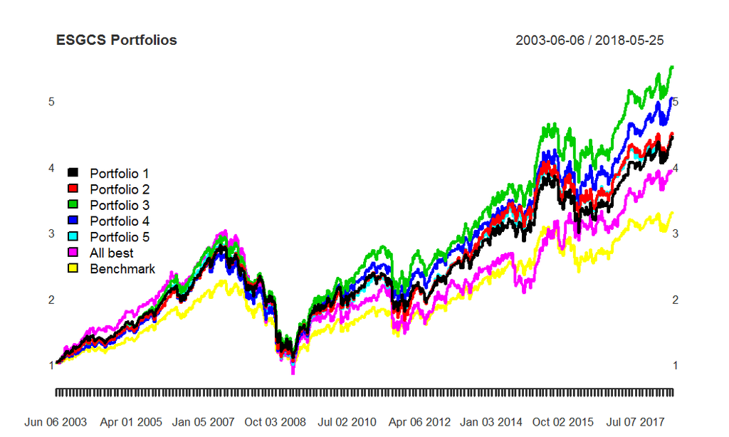

Figure 25: Cumulative Returns of ESGCS Portfolios

# Results. Stoxx Europe 600 Universe. Double-Sorted Portfolios. E

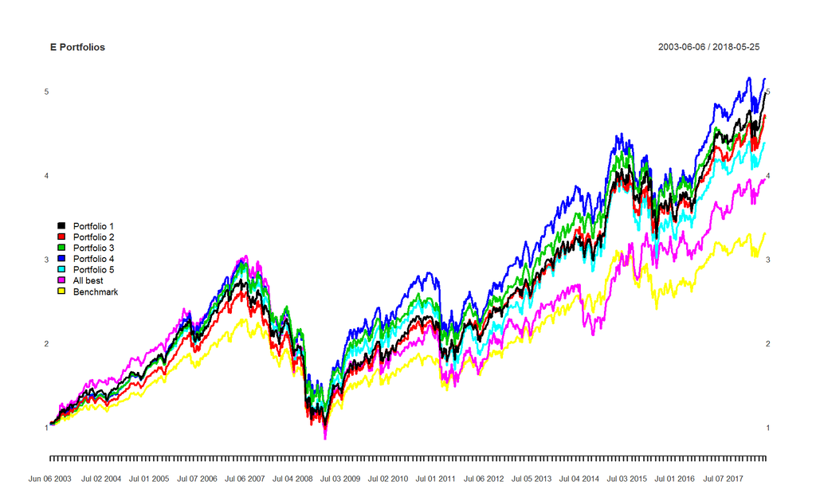

Figure 26: Cumulative Returns of E Portfolios

# Results. Stoxx Europe 600 Universe. Double-Sorted Portfolios. S

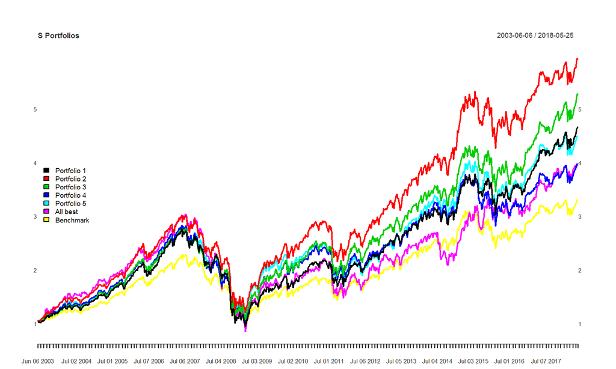

Figure 27: Cumulative Returns of S Portfolios

# Results. Stoxx Europe 600 Universe. Double-Sorted Portfolios. G

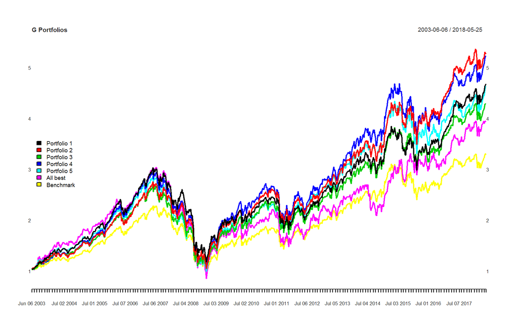

Figure 28: Cumulative Returns of G Portfolios

# Results. Stoxx Europe 600 Universe. Double-Sorted Portfolios. ESG

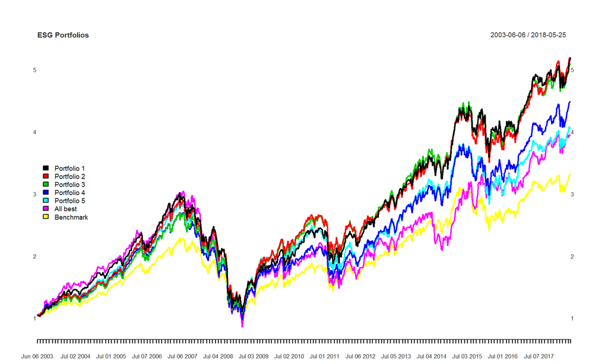

Figure 29: Cumulative Returns of ESG Portfolios

# Results. Stoxx Europe 600 Universe. Double-Sorted Portfolios. Equal ESG

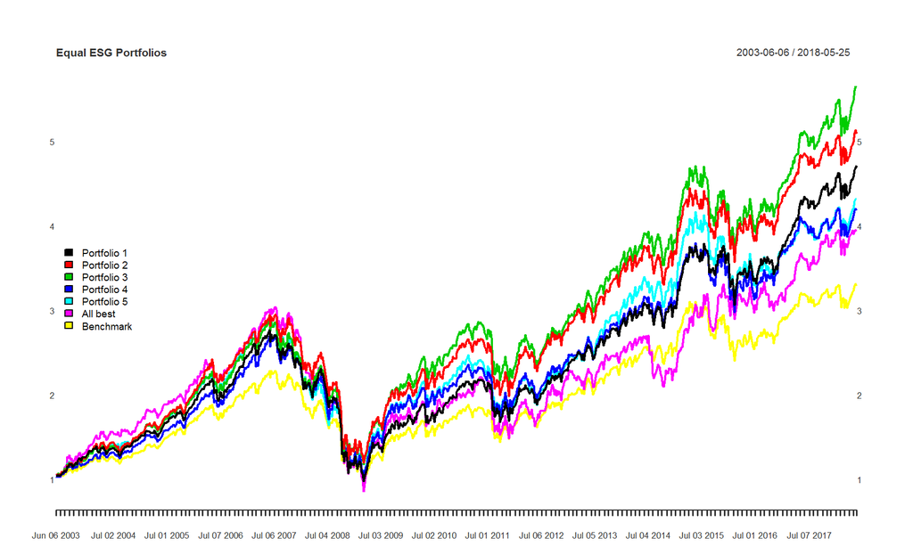

Figure 30: Cumulative Returns of Equal ESG Portfolios

# Results. Stoxx Europe 600 Universe. Double-Sorted Portfolios. Average Annual Return

Tables 35-37 show average annual return, annual standard deviation and Sharpe ratio for double-sorted portfolios.

Table 35: Average Annual Return

|  | esgcs | esg | e | s | g | equal_esg |
| --- | --- | --- | --- | --- | --- | --- |
| **Portfolio 1** | 11.75 | 12.7 | 12.45 | 12.02 | 11.94 | 12.03 |
| **Portfolio 2** | 11.96 | 12.68 | 12.08 | 13.73 | 12.86 | 12.61 |
| **Portfolio 3** | 13.16 | 12.72 | 12 | 12.97 | 11.53 | 13.39 |
| **Portfolio 4** | 12.66 | 11.91 | 12.85 | 11.08 | 13.15 | 11.49 |
| **Portfolio 5** | 11.89 | 11.41 | 12.04 | 11.95 | 12.25 | 11.83 |

Based on average annual return, no patterns are defined.

# Results. Stoxx Europe 600 Universe. Double-Sorted Portfolios. Annual Standard Deviation

Table 36: Annual Standard Deviation

|  | esgcs | esg | e | s | g | equal_esg |
| --- | --- | --- | --- | --- | --- | --- |
| **Portfolio 1** | 18.66 | 18.37 | 18.49 | 18.55 | 18.04 | 18.25 |
| **Portfolio 2** | 19.65 | 18.45 | 18.74 | 19.28 | 18.76 | 18.7 |
| **Portfolio 3** | 18.96 | 19.37 | 18.43 | 19.43 | 19.01 | 19.21 |
| **Portfolio 4** | 19.12 | 19.44 | 19.59 | 19.32 | 20.54 | 19.61 |
| **Portfolio 5** | 19.49 | 20.37 | 20.83 | 19.61 | 20.08 | 20.29 |

# Results. Stoxx Europe 600 Universe. Double-Sorted Portfolios. Sharpe Ratio

Table 37: Sharpe Ratio

|  | esgcs | esg | e | s | g | equal_esg |
| --- | --- | --- | --- | --- | --- | --- |
| **Portfolio 1** | 0.58 | 0.64 | 0.62 | 0.59 | 0.61 | 0.6 |
| **Portfolio 2** | 0.56 | 0.63 | 0.59 | 0.66 | 0.63 | 0.62 |
| **Portfolio 3** | 0.64 | 0.61 | 0.6 | 0.62 | 0.55 | 0.64 |
| **Portfolio 4** | 0.61 | 0.56 | 0.6 | 0.52 | 0.59 | 0.53 |
| **Portfolio 5** | 0.56 | 0.51 | 0.53 | 0.56 | 0.56 | 0.53 |

Portfolio 1 has greater Sharpe ratio than portfolio 5.

# Results. Stoxx Europe 600 Universe. Double-Sorted Portfolios. Benchmark and All-Best Portfolio Statistics

The table 38 contains statistics for the benchmark Stoxx Europe 600 index and the all-best portfolio. The all-best portfolio has the highest annual standard deviation and the lowest Sharpe ratio.

Table 38: Benchmark and All-Best Portfolio Statistics

|  | benchmark | all_best_portfolio |
| --- | --- | --- |
| **Average Annual Return** | 9.56 | 11.88 |
| **Annual Standard Deviation** | 17.88 | 23.1 |
| **Sharpe Ratio** | 0.48 | 0.47 |

# Results. Stoxx Europe 600 Universe. Double-Sorted Portfolios. Average Sustainability Score

Tables 39-42 illustrate average sustainability, size, value and momentum scores for constructed portfolios.

# Results. Stoxx Europe 600 Universe. Double-Sorted Portfolios. Average Sustainability Score

Table 39: Average Sustainability Score

|  | esgcs | esg | e | s | g | equal_esg |
| --- | --- | --- | --- | --- | --- | --- |
| **Portfolio 1** | 31.61 | 38.05 | 27.76 | 29.93 | 18.52 | 31.8 |
| **Portfolio 2** | 41.86 | 52.68 | 58.65 | 62.37 | 42.9 | 57.92 |
| **Portfolio 3** | 50.21 | 61.08 | 77.22 | 78.2 | 61.57 | 70.75 |
| **Portfolio 4** | 60.75 | 68.46 | 87.97 | 88.08 | 75.22 | 79.7 |
| **Portfolio 5** | 71.67 | 76.86 | 92.52 | 93.69 | 86.08 | 86.93 |

We can see that portfolios differ significantly based on the average sustainability score.

# Results. Stoxx Europe 600 Universe. Double-Sorted Portfolios. Average Size Score

Table 40: Average Size Score

|  | esgcs | esg | e | s | g | equal_esg |
| --- | --- | --- | --- | --- | --- | --- |
| **Portfolio 1** | 0.0229 | 0.0171 | 0.0183 | 0.0184 | 0.0209 | 0.0185 |
| **Portfolio 2** | 0.0297 | 0.0217 | 0.0193 | 0.0234 | 0.025 | 0.0235 |
| **Portfolio 3** | 0.0252 | 0.0238 | 0.0277 | 0.0278 | 0.0266 | 0.0259 |
| **Portfolio 4** | 0.0223 | 0.0285 | 0.0277 | 0.0272 | 0.0271 | 0.0279 |
| **Portfolio 5** | 0.0247 | 0.0319 | 0.0302 | 0.0268 | 0.0243 | 0.0277 |

Regarding the average size score, portfolio 5 always has higher score than portfolio 1.

# Results. Stoxx Europe 600 Universe. Double-Sorted Portfolios. Average Value Score

Table 41: Average Value Score

|  | esgcs | esg | e | s | g | equal_esg |
| --- | --- | --- | --- | --- | --- | --- |
| **Portfolio 1** | 0.3773 | 0.3773 | 0.3781 | 0.3784 | 0.3768 | 0.3784 |
| **Portfolio 2** | 0.3769 | 0.3782 | 0.3782 | 0.3775 | 0.3772 | 0.378 |
| **Portfolio 3** | 0.3781 | 0.3778 | 0.377 | 0.3772 | 0.3783 | 0.3766 |
| **Portfolio 4** | 0.3772 | 0.3768 | 0.3768 | 0.3768 | 0.3768 | 0.3767 |
| **Portfolio 5** | 0.3769 | 0.3763 | 0.3763 | 0.3765 | 0.3772 | 0.3767 |

However, the portfolios have almost the same average value and momentum scores.

# Results. Stoxx Europe 600 Universe. Double-Sorted Portfolios. Average Momentum Score

Table 42: Average Momentum Score

|  | esgcs | esg | e | s | g | equal_esg |
| --- | --- | --- | --- | --- | --- | --- |
| **Portfolio 1** | 0.4139 | 0.415 | 0.4149 | 0.415 | 0.4142 | 0.4147 |
| **Portfolio 2** | 0.4133 | 0.4153 | 0.4147 | 0.4155 | 0.4143 | 0.4151 |
| **Portfolio 3** | 0.4148 | 0.4146 | 0.4141 | 0.4146 | 0.4137 | 0.4145 |
| **Portfolio 4** | 0.4143 | 0.4132 | 0.4142 | 0.413 | 0.4147 | 0.4133 |
| **Portfolio 5** | 0.4136 | 0.4122 | 0.412 | 0.4122 | 0.4134 | 0.4125 |